# Statistical Methods in Data Science 2: Final Project

Claudio Battiloro

10 luglio 2019

[figure not shown]

# 1 The data

This in-depth fully Bayesian analysis is on data that are the result of a NIST study involving circular interference transmittance. The response variable ($Y_i$) is transmittance ($\in[0,1]$), and the predictor variable ($x_i$) is wavelength (cm, $\in \mathbb{R}^+$); there are $N=35$ observations. We decided to consider the following regression model:

$$Y_i \sim Beta(a_{y_i}, b_{y_i}) \\ \mu_i =\frac{a_{y_i}}{a_{y_i}+b_{y_i}} = f(x_i) = \frac{\beta_1}{\beta_2} \exp\bigg[-\frac{1}{2}\bigg(\frac{x_i-\beta_3}{\beta_2}\bigg)^2\bigg]\\ \sigma_{y_i}^2 = \frac{a_{y_i}b_{y_i}}{(a_{y_i}+b_{y_i})^2(a_{y_i}+b_{y_i}+1)}$$

From which, with an easy reparametrization:

$$a_{y_i}=\left(\frac{1-\mu_i}{\sigma_{y_i}^2}-\frac{1}{\mu_i}\right)\mu_i^2 \\
b_{y_i}=a_{y_i}\left(\frac{1}{\mu_i}-1\right)$$

Observe that the previous choice of $Y_i$ priors gives some constraints on the parameters space, in particular $\mu_i$s have to be $\in [0,1]$ and $\sigma_{y_i}^2 \in [0,.25]$ and this leads to $0\leq\beta1\leq\beta_2$. For each of them, we chose the support bounds based on intervals around the solutions given by a non linear least square procedure (more in the next paragraph).

In the end, the model parameters are $\beta_1 \in (1,2)$,$\beta_2 \in (2, 6)$,$\beta_3 \in (400,500)$, $\sigma_{y_i}^2 \in (0,.25)$.Let us consider the following prior distributions (clearly they’re truncated normals):
$$\beta_1 \sim N(\hat{\beta_{1}},\sigma^2_{\beta_1}) \\ \beta_2 \sim N(\hat{\beta_{2}},\sigma^2_{\beta_2}) \\ \beta_3 \sim N(\hat{\beta_{3}},\sigma^2_{\beta_3}) \\
\sigma_{y_i}^2 \sim N(0, \sigma_{\sigma_y}^2)$$

where $\hat{\beta_{i}},\, i =1,2,3$ are the NLS results.

In this way, it’s legit assuming marginal independence among parameters.

# 2 The model intuition

First of all, let’s take a look at the data:

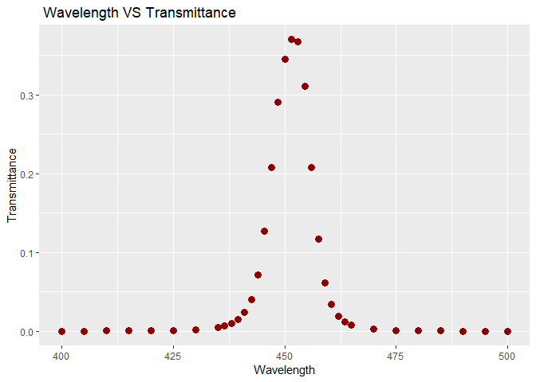

From this simple scatterplot it’s evident that a linear model will not work too well. To better understand the intuition behind the proposed regression model, we can stop being pure statistician for a minute and search only for the best $\hat{f}(x)$ using a Non Linear Least Square:

$$\DeclareMathOperator*{\argmin}{arg\,min} \hat{f}(x_i) = \frac{\hat{\beta_1}}{\hat{\beta_2}}\exp\bigg[-\frac{1}{2}\bigg(\frac{x_i-\hat{\beta_3}}{\hat{\beta_2}}\bigg)^2\bigg]\\ [\hat{\beta_1},\hat{\beta_2},\hat{\beta_3}] = \displaystyle\underset{[\beta_1,\beta_2,\beta_3] }\argmin || \mathbf{Y} - f(\mathbf{x})||_2^2$$

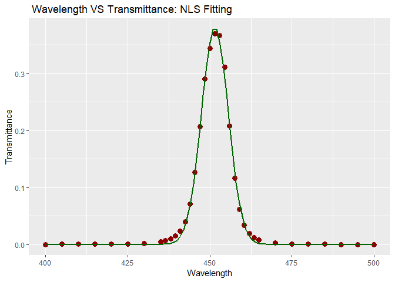

The result gives a first visual impression of the goodness of the model.

# 3 Exploratory Analysis

Before going deeper in Bayesian Inference it’s useful to explore the dataset with some standard plots and summary statistics (also for the independent variable, just to have a global view).

Let’s check the basic summaries:

|  | Transmittance | Wavelength |
| --- | --- | --- |
| X | Min. :0.0000710 | Min. :400.0 |
| X.1 | 1st Qu.:0.0004748 | 1st Qu.:437.2 |
| X.2 | Median :0.0097302 | Median :450.0 |
| X.3 | Mean :0.0758105 | Mean :450.0 |
| X.4 | 3rd Qu.:0.0938456 | 3rd Qu.:462.8 |
| X.5 | Max. :0.3698049 | Max. :500.0 |

And the variabilities of our data:

|  | Summaries |
| --- | --- |
| Wavelength Variance | 596.544118 |
| Wavelength Sd | 24.424253 |
| Transmittance Variance | 0.014663 |
| Transmittance Sd | 0.121091 |

As we can see, there is pretty high variability in the data given their scales.

Moreover, we’re interested in analyzing the skeweness and the “tailedness” of the empirical distro (using Kurtosis measure). Just for completeness, remember that:

- **Skewness** is a measure of the asymmetry of the probability distribution of a real-valued random variable about its mean. The skewness value can be positive or negative, or undefined.

For a unimodal distribution, negative skew commonly indicates that the tail is on the left side of the distribution, and positive skew indicates that the tail is on the right.

It is defined as:
$${\displaystyle \gamma _{1}=\operatorname {E} \left[\left({\frac {X-\mu }{\sigma }}\right)^{3}\right]}$$

- **Kurtosis** is a measure of the “tailedness” of the probability distribution of a real-valued random variable.

The kurtosis of any univariate normal distribution is 3. It is common to compare the kurtosis of a distribution to this value. Distributions with kurtosis less than 3 are said to be *platykurtic*, although this does not imply the distribution is “flat-topped” as sometimes reported. Rather, it means the distribution produces fewer and less extreme outliers than does the normal distribution.Distributions with kurtosis greater than 3 are said to be leptokurtic.

It is defined as:

$${\textstyle \operatorname {Kurt} =\operatorname {E} \left[\left({\frac {X-\mu }{\sigma }}\right)^{4}\right]}$$

We obtained:

|  | Transmittance.Summaries |
| --- | --- |
| Skewness | 1.5612956 |
| Kurtosis - 3 | 0.6926211 |

As we can see the positive value of the skewness indicates that there is a long right tale while the positive value of the Kurtois - 3 indicates that the distro has tails approaching zero slower than a Gaussian.

In the end, let’s take a look at the [boxplot](https://en.wikipedia.org/wiki/Box_plot) of the empirical distribution:

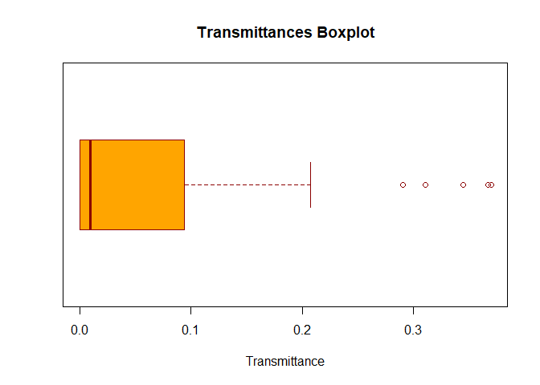

Not too much to say, obviously the informations encoded by this plot are consistent with the previous summaries.

Remember we have few data so the previous analysis has to be taken with a grain of salt.

# 4 Inference via Bayesian Network

We wanna build the Bayesian Network associated to the transmittance model in order to make inference on the regression parameters. We will use both OpenBUGS and RJags to show the results consistence.

Obviously, for our regression purposes, we are interested in:

$$\pi(\beta_i|\mathbf{Y}_n) = \frac{L(\beta_i)\cdot\pi(\beta_i)}{m(\mathbf{Y}_n)} = \frac{p(\mathbf{Y}_n|\beta_i)\cdot\pi(\beta_i)}{m(\mathbf{Y}_n)}, \quad i=1,2,3$$

We are interested in parameters estimates and we know that:

- The mean of the posterior is the best estimator in the MSE sense due to the fact that:

$$\operatorname{E}[\boldsymbol{\beta}|\mathbf{Y}_n]= \arg\min_{d} [\operatorname{MSE(\boldsymbol{\beta},d(\mathbf{Y}_n))]}$$

- The median of the posterior is the best estimator in the Absolute Loss ($L_1$) sense due to the fact that:

$$\operatorname{Median}[\boldsymbol{\beta}|\mathbf{Y}_n]= \arg\min_{d} [\operatorname{L_1(\boldsymbol{\beta},d(\mathbf{Y}_n))]}$$

We can also get a first estimate of the $95\%$ [credible intervals](https://www.statisticshowto.data_twsciencecentral.com/credible-interval/) for $\boldsymbol{\beta}$ by looking at the indicated percentiles, hoping the posteriors are unimodal and semi-symmetric.

In general, remember that credible interval $C = [a,b]$ at level $1-\alpha$ for an unknown **random** parameter $\theta \in \mathbb{R}$ is defined as a **not random** interval that captures the $1-\alpha$ probability mass of the parameter:

$$\int_C \pi(\theta|\mathbf{X}) d\theta = 1-\alpha$$

Where $\pi$ is the posterior probability distribution of the parameter given the data $\mathbf{X}$.

## 4.1 OpenBUGS

The model can be easily structured via OpenBUGS using the following Doodle:

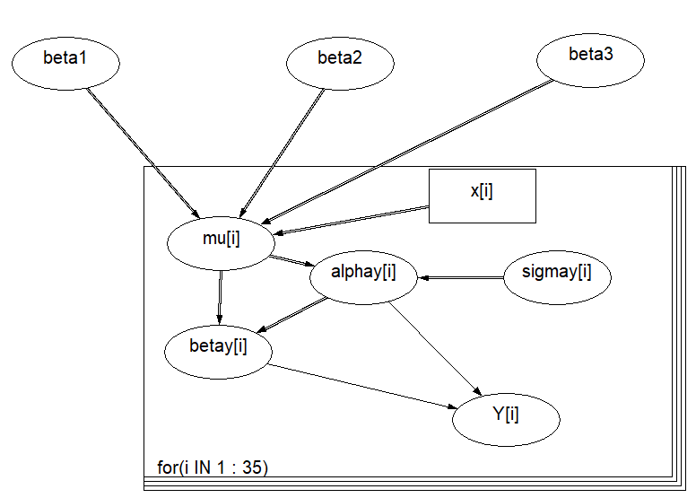

Where:

- “beta1” is is a stochastic node. It represents our prior belief about $\beta_1$ and is setted on the aforementioned correspondent distros and bounds.
- “beta2” is is a stochastic node. It represents our prior belief about $\beta_2$ and is setted on the aforementioned correspondent distros and bounds.
- “beta3” is is a stochastic node. It represents our prior belief about $\beta_3$ and is setted on the aforementioned correspondent distros and bounds.
- “sigmay[i]” is is a stochastic plate. It represents our prior belief about $\sigma^2_{y_i}$ and each element of the plate is setted on the aforementioned correspondent distros and bounds.
- “Y[i]” is a stochastic plate. It represents our dependent variable sample, so each observation is a transmittance value and is drawed from the correspondent aforementioned $Beta$ prior.
- “x[i]” is a constant plate. It represents our independent variable sample, so each observation is a wavelength value.
- “mu[i]” is a logical plate. Each element takes the parameters values and transform them via $f(x_i)$.
- “alphay[i]” and “betay[i]” are two logical plates. Their links are structured to implement the needed reparametrization to set the “Beta” prior shape and rate.

Now that we have the graphical model, we can set up all the elements we need to run the posterior sampling via Markov Chain.

The first step is loading the data, setting the constants and the initial points of the chains, in this case 3.

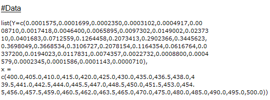

Now that we’ve loaded the data, it’s time to run the chains.

This is are the trace plots:

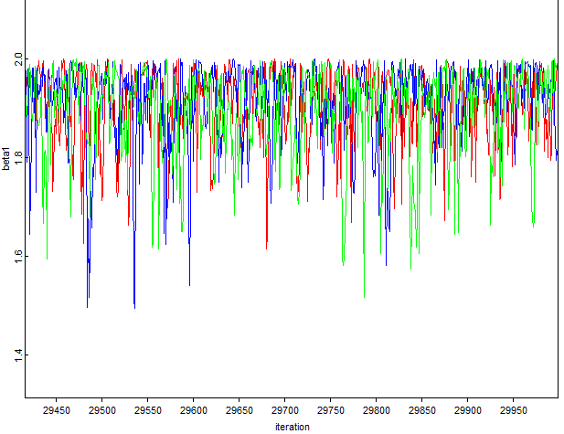

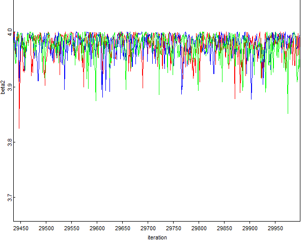

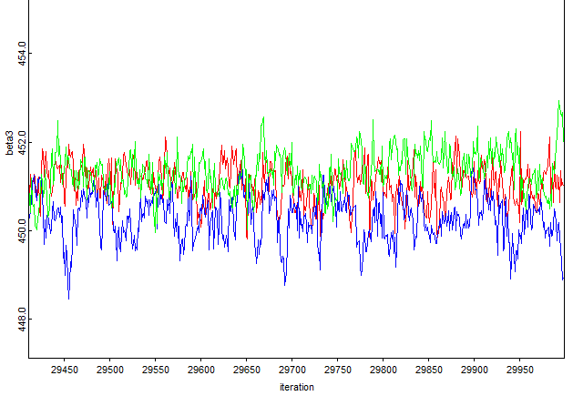

As we can see, the results seem to be acceptable, the history of the chains is what we should see, fluctuations and apparantely no correlation among samples. Anyway, let’s take a deeper look at the [autocorrelation](http://ce.sharif.ac.ir/courses/84-85/1/ce695/resources/root/R.P%20Concepts/m10676.pdf) of the process:

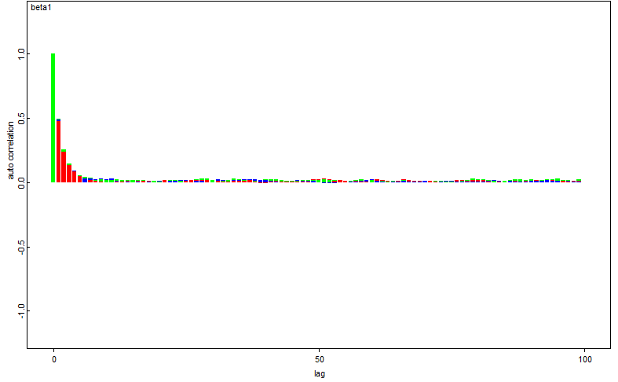

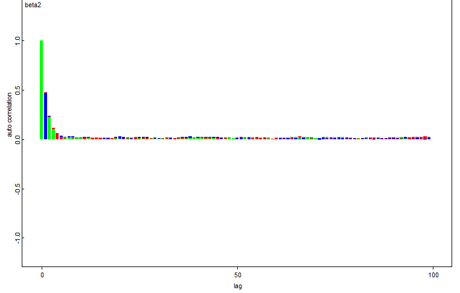

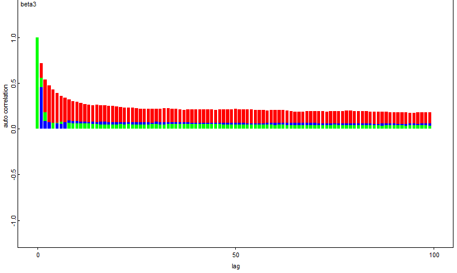

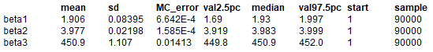

They’re pretty similiar to the results of the NLS. Let’s check if we can do better, also in terms of analysis, using RJags.

## 4.2 RJags

The previous Doodle can be implemented using RJags as follows:

- Data structuring as requested:

```r
data_tw_jags=list(Y=Y, x=X) # Load the data
```

- Model definition:

```r
model_string <- "model{
    for( i in 1 : 35 ){
        Y[i] ~ dbeta(alphay[i], betay[i])
        sigmay[i] ~ dnorm(0.0, 1.0E-2) T(0,0.25)
        alphay[i] <- max(pow(mu[i], 2) * ((1 - mu[i]) / sigmay[i] - 1 / mu[i]), 0.000001)
        betay[i] <- alphay[i] * (1 / mu[i] - 1)
        mu[i] <- max((beta1 / beta2) * exp((-0.5) * pow((x[i] - beta3) / beta2, 2)),0.000001)
    }
  beta1 ~ dnorm(1.5, 1.0E-2) T(1,2)
    beta2 ~ dnorm(4, 1.0E2) T(2,6)
    beta3 ~ dnorm(450, 1.0E-2) T(400,500)
}"


# Alpha and Mu cut to avoid precision errors
```

Let’s run the chains :

```
##
## Iterations = 31001:61000
## Thinning interval = 1
## Number of chains = 3
## Sample size per chain = 30000
##
## 1. Empirical mean and standard deviation for each variable,
##    plus standard error of the mean:
##
##          Mean      SD  Naive SE Time-series SE
## beta1   1.912 0.07965 0.0002655      0.0006125
## beta2   4.315 0.09024 0.0003008      0.0009603
## beta3 450.723 0.51753 0.0017251      0.0094317
##
## 2. Quantiles for each variable:
##
##          2.5%     25%     50%     75%   97.5%
## beta1   1.702   1.874   1.934   1.972   1.998
## beta2   4.139   4.254   4.315   4.375   4.493
## beta3 449.705 450.393 450.711 451.050 451.779
```

At this point, before going over, in order to get a more accurate approximation analysis, it’s important to set up a burn-in for each chain (**if necessary**), so the number of higly correlated initial draws we wanna drop. To do so, we can use an R function and we’ll drop for all the chains the highest overall burn in:

|  | burn_ins |
| --- | --- |
| Beta 1 | 0 |
| Beta 2 | 0 |
| Beta 3 | 0 |

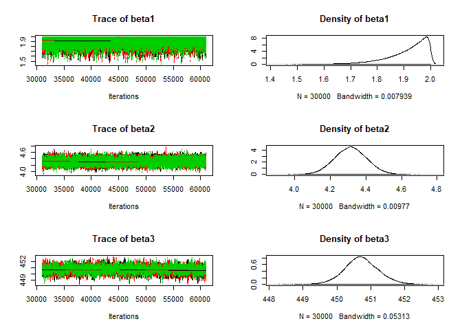

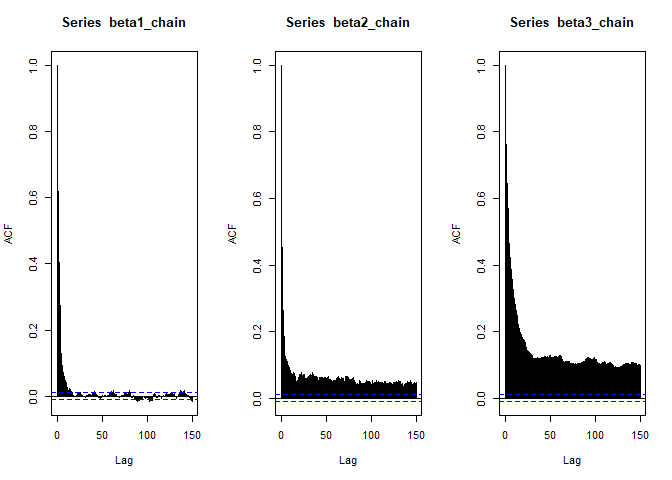

Exactly as in BUGS. But now we can go over thanks to R language versatility.

### 4.2.1 Approximation Error

In order to evaluate the approximation error, we can use the estimator on which we have more theoretical informations: the empirical average.

As we know:

$$\hat{I} = \frac{1}{t}\sum_{i=T_0+1}^{T_0+t}h(\theta_i) \xrightarrow{\text{a.s.}} E_{\pi}[h(\theta)]= I \quad \text{for }\quad t \xrightarrow{}\infty$$

Where $T_0$ is the index of the first non-burned draw. As usual, the MSE is the typical risk used and in this case:

$$\mathbb{E}[(\hat{I_n}- I)^2]=V(\hat{I_n})=\frac{1}{t_{eff}}\mathbb{V}(X)$$
where $t_{eff}$ is the effective sample size (ESS). The idea is to have a sort of “exchange rate” between dependent and independent samples. You might want to say, for example, that 1,000 samples from a certain Markov chain are worth about as much as 80 independent samples because the MCMC samples are highly correlated. Or you might want to say that 1,000 samples from a different Markov chain are worth about as much as 300 independent samples because although the MCMC samples are dependent, they’re weakly correlated. More formal details on the slides.

So let’s compute it:

| Beta 1 | Beta 2 | Beta 3 |
| --- | --- | --- |
| 5990.391 | 2478.93 | 1022.949 |

As expected, the lower is the ESS the slower is the ACF drecreasing.

But now it’s time to approximate the MSE of our estimators (system rounds to $0$ errors under $10^{-10}$):

| Beta 1 | Beta 2 | Beta 3 |
| --- | --- | --- |
| 1e-06 | 3.3e-06 | 0.0002547 |

As we can expect, $\beta_3$ uncertainty is the highest.

In the end, just to have a look, let’s check how the fitting curve look like if we use the obtained estimates:

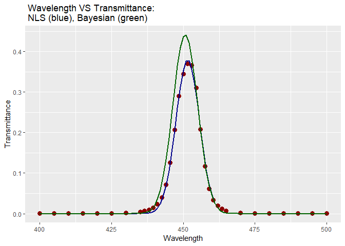

Similiar to the NLS result.The dissimilarity is due to the fact that our priors have expected value but are still left to be vague in terms of variances; this is influecing the result. In particular the main problem is the few number of data, they cannot speak completely for them selves.

### 4.2.2 Empirical Mean Behaviour

We can evaluate the behaviour of the empirical average in various ways. First of all, let’s take a look to the evolution of $\hat{I}_t$ for each parameter and each chain.

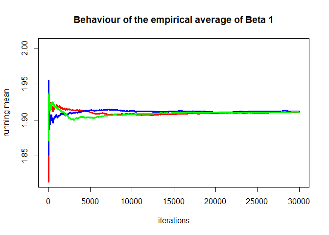

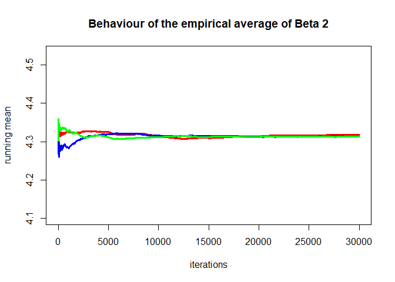

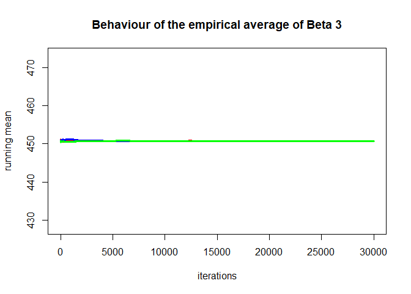

As we can see, the chains agree. Despite the fact that there are multichains methods to assess the convergence of $\hat{I}_t$ to $I$ we decided, given the low number of chains and for the sake of semplicity, to use a single chain method proposed by Yu & Mykland (1998) named “CUSUM” that gives a qulitative measure of convergence analyzing the puntual deviations of the draws (or their target transformation) from $\hat{I}_T$. More formally, it defines the time function:

$$D_T^t = \sum_{i=1}^t[h(\theta_i)-\hat{I}_T ]$$

where $t = 1,...,T$ and $T$ is the total number of simulations; in our case, obviously, $h(\theta_i) = \theta_i$.

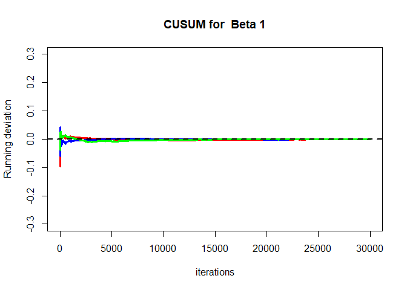

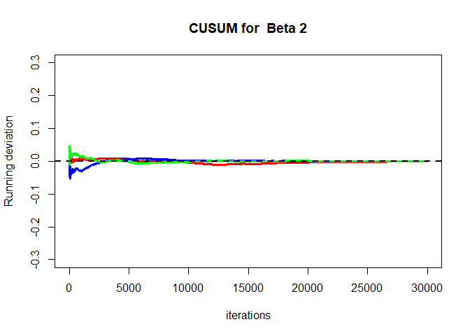

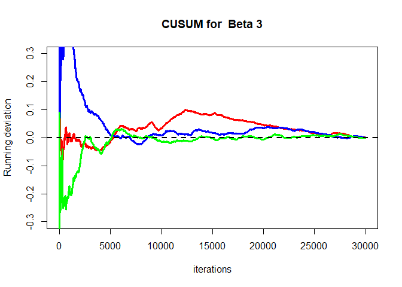

Nice, graphically we’re pretty sure that the empirical averages converge to the true one (or, better, surely the process is going to be stationary).

### 4.2.3 Posterior Uncertainty

We measure the uncertainty by using the variability of the parameter w.r.t. its absolute expectation:

$$U = \mathbb{V}\{\hat{\theta}\}^{1/2}/|\mathbb{E}\{\hat{\theta}\}|$$

Obviously we can use the plug in estimators (empirical sd and expectation) given by the chains:

| Beta 1 | Beta 2 | Beta 3 |
| --- | --- | --- |
| 0.0412308 | 0.0208065 | 0.0011326 |

We see that the highest posterior uncertainty is given by $\beta_1$

### 4.2.4 Parameters Correlation

We can just take the a corplot and compute the empirical covariance matrix using the chains. In this case, we’re looking for a linear correlation and we know that the basic plug in estimator for the Pearson coefficients requires the samples being of the same size so we decided to cut all the chains using the overall highest burn in.

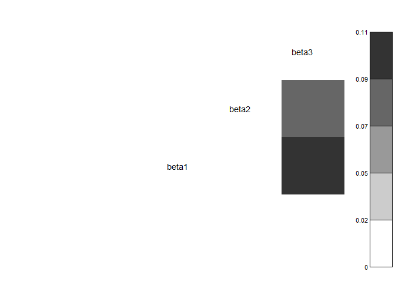

|  | Beta 1 | Beta 2 | Beta 3 |
| --- | --- | --- | --- |
| Beta 1 | 1.0000000 | -0.0033902 | -0.1080870 |
| Beta 2 | -0.0033902 | 1.0000000 | -0.0669723 |
| Beta 3 | -0.1080870 | -0.0669723 | 1.0000000 |

As we can see, the most correlated ones are $\beta_1$ and $\beta_3$.

# 5 What about predictions?

In this small paragraph we wanna **only illustrate** how using the Markov chain to approximate the posterior predictive distribution of the transmittance correspondent to a wavelength $\tilde{x}$. So we wanna approximate:

$$m(y_{new}) = \int_\Theta f(y_{new}|\theta,Y_{old},\tilde{x})\pi(\theta) d\theta$$

Where, in this case, $\theta = [\beta_1,\beta_2,\beta_3,\sigma_{y_i}^2]$, $\Theta$ is the parameter space (the set in $\mathbb{R}^4$ individuated by the parameters ranges) and $\pi(\theta)$ is the product of the priors thank to marginal independence assumption. We can easily do this with Ancestral Sampling. Briefly, the procedure is sampling from $\pi(\theta)$ and then from $f(y_{new}|\theta,Y_{old},\tilde{x})$. Substantially, we wanna show that sampling from a joint distro and then taking in consideration only one of the involved R.V. s corresponds to sampling from its marginal.

To better have an intuition on why this methods work we can make a dumb example that can be generalized without difficulty. Suppose $Y \in \mathbb{R}^d$ and $\theta \in \Theta$ are two discrete random variables, then, for the law of total probability holds:

$$P(Y=y)= \sum_{\Theta}P(Y=y|\theta)P(\theta) = \sum_{i=1}^{|\Theta|}P(Y|\theta_i)P(\theta_i)$$

We know that the plug in estimator of $P(\theta=\theta_i) = {\mathbb{E}\{\mathbb{I}(\theta=\theta_k)\}}$ is just the relative frequency $\hat{P}(\theta=\theta_k) = \frac{1}{N}\sum_{j=1}^N \mathbb{I}(\theta_j=\theta_k)$ and, consequentialy,having $N$ data points $\{Y_i,\theta_i\}_{i=1}^N\sim j(Y,\theta)$,:

$$\hat{P}(Y=y|\theta=\theta_k) = \frac{1}{M}\sum_{i=1}^N \mathbb{I}(Y_i=y) \mathbb{I}(\theta_i=\theta_k)$$

where $M= \sum_{i=1}^N\mathbb{I}(\theta_i=\theta_k)$. In the end:

$$\hat{P}(Y=y) = \sum_\Theta \hat{P}(Y = y|\theta)\hat{P}(\theta)= \sum_{k=1}^{|\Theta|}\Bigg[\frac{1}{M}\sum_{i=1}^N \mathbb{I}(Y_i=y) \mathbb{I}(\theta_i=\theta_k)\Bigg]\frac{1}{N}\sum_{j=1}^N\mathbb{I}(\theta_j=\theta_k) = \\ = \sum_{k=1}^{|\Theta|}\Bigg[\frac{1}{M}\sum_{i=1}^N \mathbb{I}(Y_i=y) \mathbb{I}(\theta_i=\theta_k)\Bigg]\frac{M}{N} = \frac{1}{N}\sum_{k=1}^{|\Theta|}\sum_{i=1}^N \mathbb{I}(Y_i=y) \mathbb{I}(\theta_i=\theta_k) = \\ = \frac{1}{N}\sum_{i=1}^N \mathbb{I}(Y_i=y)\sum_{k=1}^{|\Theta|}\mathbb{I}(\theta_i=\theta_k) = \frac{1}{N}\sum_{i=1}^N \mathbb{I}(Y_i=y) \cdot 1 = \\ = \frac{1}{N}\sum_{i=1}^N \mathbb{I}(Y_i=y)$$

That is exactly the plug in estimator of $P(Y=y)$. This dumb “proof” can be easily extended to the continuous case, as the one for or model is.

# 6 A second model

We can try to use another simple model by just imposing normal likelihood over $Y_i$ and check what happens. So We are considering the following regression model:

$$Y_i \sim N(\mu_i, \sigma_{y_i})T[0,1] \\ \mu_i = f(x_i) = \frac{\beta_1}{\beta_2} \exp\bigg[-\frac{1}{2}\bigg(\frac{x_i-\beta_3}{\beta_2}\bigg)^2\bigg]$$

Again the physical nature of $Y_i$ gives some constraints on the parameters space, in particular $\mu_i$s have to be $\in [0,1]$ and this leads to $0\leq\beta1\leq\beta_2$. Again, for each of them, we chose the bounds based on intervals around the solutions given a non linear least square procedure. In the end, the model parameters are $\beta_1 \in (1,2)$,$\beta_2 \in (2, 6)$,$\beta_3 \in (400,500)$, $\sigma_{y_i}^2 \in (0,.25)$. Let us consider the following prior distributions (clearly they’re truncated normals):
$$\beta_1 \sim N(\hat{\beta_{1}},\sigma^2_{\beta_1}) \\ \beta_2 \sim N(\hat{\beta_{2}},\sigma^2_{\beta_2}) \\ \beta_3 \sim N(\hat{\beta_{3}},\sigma^2_{\beta_3}) \\
\sigma_{y_i}^2 \sim N(0, \sigma_{\sigma_y}^2)$$

where $\hat{\beta_{i}},\, i =1,2,3$ are the NLS results.

We assume again marginal independence among parameters.

As before, the most suitable choice for the hyperparameters is the one that guarantees pretty “vague” (high variance) priors:

```r
model_string2 <- "model{
    for( i in 1 : 35 ){
        Y[i] ~ dnorm(mu[i], 1/sigmay[i]) T(0,1)
        sigmay[i] ~ dnorm(0.0, 1.0E-5) T(0,100)
        mu[i] <- (beta1 / beta2) * exp((-0.5) * pow((x[i] - beta3) / beta2, 2))
    }
  beta1 ~ dnorm(1.5, 1.0E-2) T(1,2)
    beta2 ~ dnorm(4, 1.0E-2) T(2,6)
    beta3 ~ dnorm(450, 1.0E-2) T(400,500)
}"
```

```
##
## Iterations = 11001:21000
## Thinning interval = 1
## Number of chains = 3
## Sample size per chain = 10000
##
## 1. Empirical mean and standard deviation for each variable,
##    plus standard error of the mean:
##
##          Mean      SD Naive SE Time-series SE
## beta1   1.500  0.2889 0.001668       0.001995
## beta2   3.998  1.1506 0.006643       0.007845
## beta3 449.999 10.0316 0.057917       0.075173
##
## 2. Quantiles for each variable:
##
##          2.5%     25%     50%     75%   97.5%
## beta1   1.025   1.249   1.499   1.751   1.975
## beta2   2.099   3.006   4.010   4.988   5.905
## beta3 430.028 443.323 450.013 456.744 469.572
```

As usual, before running the analysis, in order to get a more accurate approximation analysis, it’s important to set up a burn-in for each chain (if necessary):

|  | burn_ins |
| --- | --- |
| Beta 1 | 0 |
| Beta 2 | 0 |
| Beta 3 | 0 |

Let’s take a look to the traceplots and ACFs (of one chain per parameter):

[figure not shown]

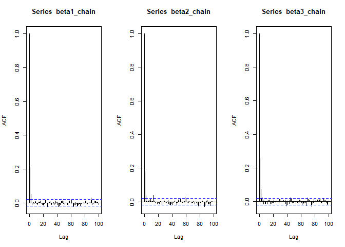

Nice, the ACF decay really fast. We could expect high values of effective sample size:

| Beta 1 | Beta 2 | Beta 3 |
| --- | --- | --- |
| 6620.959 | 7035.362 | 5587.702 |

The model seems to be better than the first one looking at this informations.

In the end, just to have a look, let’s check how the fitting curve look like if we use the obtained estimates:

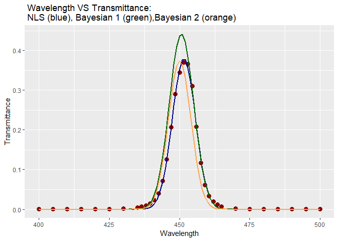

This second model fits the data very well. Let’s try to formalize this quality difference between the two models.

## 6.1 Comparing via DIC

The second model has a better fitting. We can compare the two models using [DIC](https://en.wikipedia.org/wiki/Deviance_information_criterion). Briefly, rememeber that the idea is that models with smaller DIC should be preferred to models with larger DIC.

Define the deviance as $D(\theta )=-2\log(p(y|\theta ))+C$, where $y$ are the data, $\theta$ are the unknown parameters of the model and $p(y|\theta )$ is the likelihood function. $C$ is a constant that cancels out in all calculations that compare different models, and which therefore does not need to be known.

There are two calculations in common usage for the effective number of parameters of the model. The first, as described in Spiegelhalter et al. (2002, p. 587) is $p_{D}=\bar{D}-D({\bar {\theta }})$ , where ${\bar {\theta }}$ is the expectation of $\theta$. The second, as described in Gelman et al. (2004, p. 182) is $p_{D}=p_{V}={\frac {1}{2}}{\widehat {\operatorname {var} }}\left(D(\theta )\right)$. The larger the effective number of parameters is, the easier it is for the model to fit the data, and so the deviance needs to be penalized.

The deviance information criterion is calculated as

$${\mathit {DIC}}=p_{D}+{\bar {D}}$$
, or equivalently as

$${\mathit {DIC}}=D({\bar {\theta }})+2p_{D}$$

Fot our two used models:

```
## [1] "Beta-Normal Model:"
```

```
## Mean deviance:  126.1
## penalty 25495
## Penalized deviance: 25621
```

```
## [1] "Normal-Normal Model:"
```

```
## Mean deviance:  -1.134
## penalty 58.76
## Penalized deviance: 57.62
```

# 7 A bit of frequentist analysis: Maximum Likelihood and Hypothesis Testing (Beta-Normal Model)

In this paragraph we wanna compare the obtained results from NLS and Bayesian approach with the one obtainable using MLE, so let’s proceed:

```
##
## Call:
## mle2(minuslogl = LL, start = list(b1 = 1.5, b2 = 4, b3 = 451),
##     fixed = c(sigma2y = 5e-05))
##
## Coefficients:
##    sigma2y         b1         b2         b3
##   0.000050   1.514531   4.001983 451.015824
##
## Log-likelihood: -1179.24
```

Let’s plot it togheter with the other:

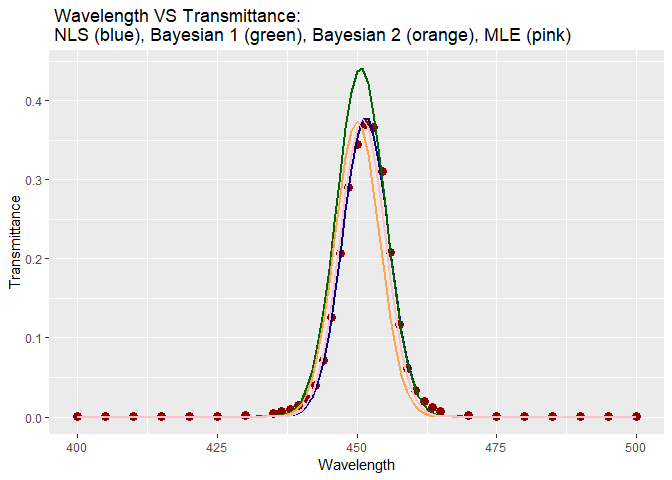

Again a very good fitting, similiar to NLS.

## 7.1 Confidence Intervals VS Credible Interval

In this paragraph we wanna continue the comparing of results obtained from the two different approaches, Bayesian and Frequentist. In particular we wanna check how the correspondent credible intervals and confidence intervals behave. Just to have a brief review, remember that they’re two completelly different object:

- A credible interval $C = [a,b]$ at level $1-\alpha$ for an unknown **random** parameter $\theta \in \mathbb{R}$ is defined as a **not random** interval that captures the $1-\alpha$ probability mass of the parameter:

$$\int_C \pi(\theta|\mathbf{X}) d\theta = 1-\alpha$$

Where $\pi$ is the posterior probability distribution of the parameter given the data $\mathbf{X}$.

In our case looking at quantiles to come out with a credible interval is not so good becouse not all the distributions of interest present high symmetry and so this interval will be not the **optimal** one. To get a better results we can use HDR whoose definition is given in [“Computing and Graphing Highest Density Regions”](https://www.tandfonline.com/doi/abs/10.1080/00031305.1996.10474359?journalCode=utas20#):

“Let $f(x)$ be the density function of a random variable $X$. Then the $100(1-\alpha)$% HDR is the subset $\mathbb{T}(f_\alpha)$ of the sample space of $X$ such that

$$\mathbb{T}(f_\alpha) = \{x\colon f(x)\geq f_\alpha\},$$
where $f_{\alpha}$ is the largest constant such that

$$P\big(X\in \mathbb{T}(f_\alpha)\big)\geq 1-\alpha.$$
"

Figure 1 from the aforementioned article illustrates the difference between the 75% HDR (so $\alpha=0.25$) and various other 75% Probability Regions for a mixture of two normals ($c_q$ is the $q-th$ quantile, $\mu$ the mean and $\sigma$ the standard deviation of the density):

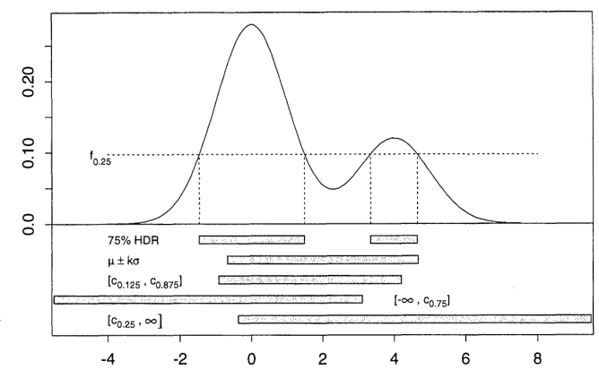

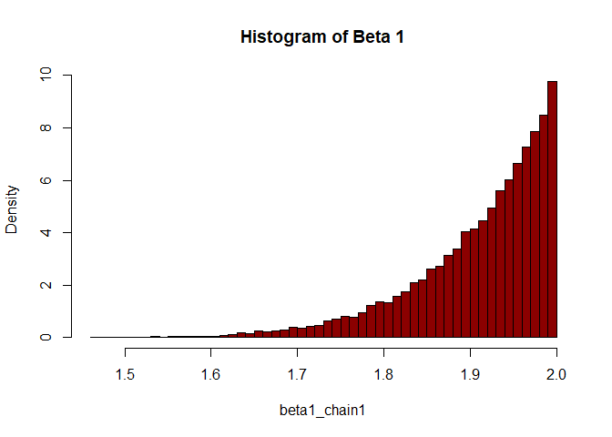

```
## [1] "Beta 1 HDR CI"
```

```
## $hdr
##                        [,1]     [,2]
## 0.949999999999995% 1.993155 1.994198
##
## $mode
## [1] 1.993543
##
## $falpha
##   99.05%
## 9.479721
```

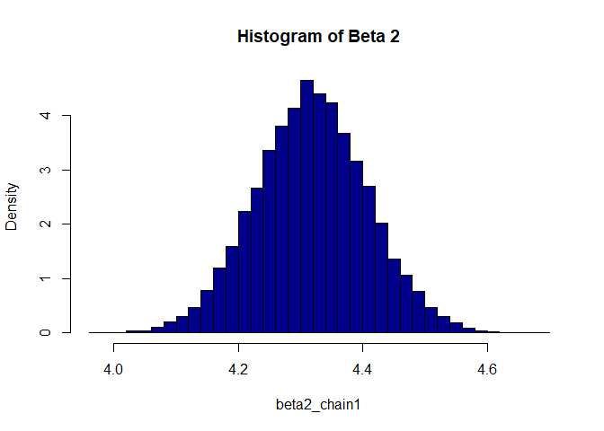

[output not shown]

```
## $hdr
##                        [,1]    [,2]
## 0.949999999999995% 4.316709 4.31859
##
## $mode
## [1] 4.317849
##
## $falpha
##   99.05%
## 3.737268
```

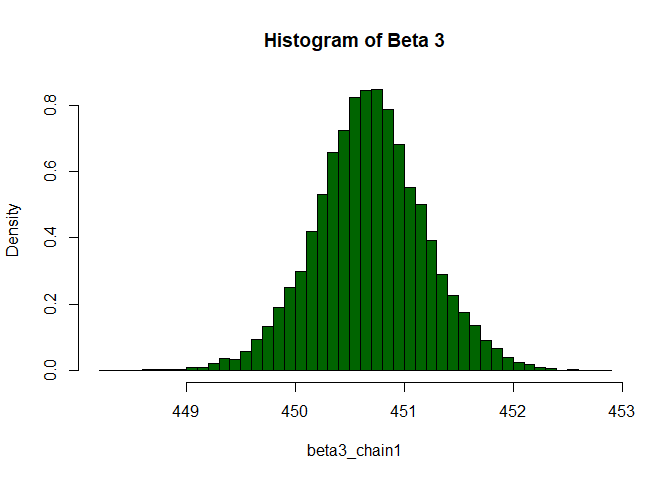

[output not shown]

```
## $hdr
##                        [,1]     [,2]
## 0.949999999999995% 450.6691 450.6796
##
## $mode
## [1] 450.6759
##
## $falpha
##    99.05%
## 0.7856763
```

- A confidence interval $C = [a,b]$ at level $1-\alpha$ for an unknown **not random** parameter $\theta \in \mathbb{R}$ is defined as a **random** interval that traps the true $\theta$ with probability $1-\alpha$:

$$\mathbb{P}_C(\theta\in C) = 1-\alpha$$

In our case we can easily get a Confidence Interval for the parameters because we estimated them using MLE. All of the MLE estimators are asymptotically normal and this means we can get **asymptotic** confidence interval for them. More formally, given $\theta_{ML}$ the MLE estimator of a **not random** parameter $\theta$, it will be asymptotically distributed as:

$$\theta_{ML} \sim_{n \uparrow} N(\theta, se_{\theta_{ML}})$$

We have few data and we have to estimate $se_{\theta_{ML}}$. We can get an estimate using nonparametric Bootstrap:

```r
X=data_tw$Wavelength
Y=data_tw$Transmittance
# Bootstrap with lib
 sk_boot_beta1 <- function(x,idx){
 LL <- function(sigma2y,b1,b2,b3) {
    muy = (b1/b2)*exp((-.5)*((X[idx]-b3)/b2)^2)
    ay = max(((1-muy)/sigma2y-1/muy)*muy^2,.001)
    by = ay*(1/muy-1)
    L = dbeta(x[idx], ay, by)
    L[which(L==0)] = .Machine$double.eps
    -sum(log(L))
 }

ml <- mle2(LL, start = list(b1 = 1.5 , b2 = 4, b3=451), fixed = c(sigma2y=.00005))

return (as.numeric(ml@coef[1]))
 }

sk_boot_beta2 <- function(x,idx){
 LL <- function(sigma2y,b1,b2,b3) {
    muy = (b1/b2)*exp((-.5)*((X[idx]-b3)/b2)^2)
    ay = max(((1-muy)/sigma2y-1/muy)*muy^2,.001)
    by = ay*(1/muy-1)
    R = dbeta(x[idx], ay, by)
    R[which(R==0)] = .Machine$double.eps
    -sum(log(R))
 }

ml <- mle2(LL, start = list(b1 = 1.5 , b2 = 4, b3=451), fixed = c(sigma2y=.00005))
   return (as.numeric(ml@coef[2]))
}

sk_boot_beta3 <- function(x,idx){
 LL <- function(sigma2y,b1,b2,b3) {
    muy = (b1/b2)*exp((-.5)*((X[idx]-b3)/b2)^2)
    ay = max(((1-muy)/sigma2y-1/muy)*muy^2,.001)
    by = ay*(1/muy-1)
    R = dbeta(x[idx], ay, by)
    R[which(R==0)] = .Machine$double.eps
    -sum(log(R))
 }

ml <- mle2(LL, start = list(b1 = 1.5 , b2 = 4, b3=451), fixed = c(sigma2y=.00005))
return (as.numeric(ml@coef[3]))
 }



sk_lib1 <- boot::boot(Y,statistic = sk_boot_beta1, R =15, parallel = "snow")
ci1 <- boot::boot.ci(sk_lib1, conf = 0.95, type = c("norm"))

sk_lib2 <- boot::boot(Y,statistic = sk_boot_beta2, R = 15, parallel = "snow")
ci2 <- boot::boot.ci(sk_lib2, conf = 0.95, type = c("norm"))

sk_lib3 <- boot::boot(Y,statistic = sk_boot_beta3, R = 15, parallel = "snow")
ci3 <- boot::boot.ci(sk_lib3, conf = 0.95, type = c("norm"))


ci_n <- data.frame(rbind(ci1$normal,ci2$normal,ci3$normal))
colnames(ci_n) <- c("Level","Lower","Upper")
rownames(ci_n) <- c("Beta1","Beta2","Beta3")
kable(ci_n)
```

|  | Level | Lower | Upper |
| --- | --- | --- | --- |
| Beta1 | 0.95 | -69.92111 | 67.89644 |
| Beta2 | 0.95 | -942.01669 | 941.39577 |
| Beta3 | 0.95 | -1535.91170 | 1612.34221 |

As we can see, the approximation is not so good and the ci span on the whole parameters range. This is caused by various factors. First of all, there are very few data; moreover, the estimates are obtained through numerical optimization on very small scale of independent variables (and so of parameters), in the end an hard numeric problem. In this case more sophisticated techniques are needed, but what we showed is one of the possible approaches to face the computation of confidence intervals.